# Abstract

## MODEL BUILDING

```python
X = df.drop(columns=['Stage'], axis=1)
X
```

|  | N_Days | Status | Drug | Age | Sex | Ascites | Hepatomegaly | Spiders | Edema | Bilirubin | Cholesterol | Albumin | Copper | Alk_Phos | SGOT | Tryglicerides | Platelets | Prothrombin |
| --- | --- | --- | --- | --- | --- | --- | --- | --- | --- | --- | --- | --- | --- | --- | --- | --- | --- | --- |
| 0 | 2221 | 0 | 1 | 18499 | 0 | 0 | 1 | 0 | 0 | 0.5 | 149.000000 | 4.04 | 227.0 | 598.0 | 52.70 | 57.000000 | 256.0 | 9.9 |
| 1 | 1230 | 0 | 1 | 19724 | 1 | 1 | 0 | 1 | 0 | 0.5 | 219.000000 | 3.93 | 22.0 | 663.0 | 45.00 | 75.000000 | 220.0 | 10.8 |
| 2 | 4184 | 0 | 1 | 11839 | 0 | 0 | 0 | 0 | 0 | 0.5 | 320.000000 | 3.54 | 51.0 | 1243.0 | 122.45 | 80.000000 | 225.0 | 10.0 |
| 3 | 2090 | 2 | 1 | 16467 | 0 | 0 | 0 | 0 | 0 | 0.7 | 255.000000 | 3.74 | 23.0 | 1024.0 | 77.50 | 58.000000 | 151.0 | 10.2 |
| 4 | 2105 | 2 | 1 | 21699 | 0 | 0 | 1 | 0 | 0 | 1.9 | 486.000000 | 3.54 | 74.0 | 1052.0 | 108.50 | 109.000000 | 151.0 | 11.5 |
| ... | ... | ... | ... | ... | ... | ... | ... | ... | ... | ... | ... | ... | ... | ... | ... | ... | ... | ... |
| 24995 | 3584 | 2 | 0 | 23612 | 0 | 0 | 0 | 0 | 0 | 0.8 | 231.000000 | 3.87 | 173.0 | 9009.8 | 127.71 | 96.000000 | 295.0 | 11.0 |
| 24996 | 3584 | 2 | 0 | 23612 | 0 | 0 | 0 | 0 | 0 | 0.8 | 231.000000 | 3.87 | 173.0 | 9009.8 | 127.71 | 96.000000 | 295.0 | 11.0 |
| 24997 | 971 | 2 | 0 | 16736 | 0 | 0 | 1 | 1 | 2 | 5.1 | 369.510563 | 3.23 | 18.0 | 790.0 | 179.80 | 124.702128 | 104.0 | 13.0 |
| 24998 | 3707 | 0 | 0 | 16990 | 0 | 0 | 1 | 0 | 0 | 0.8 | 315.000000 | 4.24 | 13.0 | 1637.0 | 170.50 | 70.000000 | 426.0 | 10.9 |
| 24999 | 3707 | 0 | 0 | 16990 | 0 | 0 | 1 | 0 | 0 | 0.8 | 315.000000 | 4.24 | 13.0 | 1637.0 | 170.50 | 70.000000 | 426.0 | 10.9 |

25000 rows × 18 columns

###### we removed stage column for dependent variable(target_feature )(Y_Train,Y_Test)

###### and the remain column will be independent variable (prediction_feature) (X_train,X_test)

```python
y = df['Stage']
y
```

```
0        1
1        2
2        2
3        2
4        1
        ..
24995    2
24996    2
24997    3
24998    2
24999    2
Name: Stage, Length: 25000, dtype: int64
```

```python
print(y.shape)
print(y.values)
```

```
(25000,)
[1 2 2 ... 3 2 2]
```

```python
print(X.shape)
print(X.values)
```

```
(25000, 18)
[[2.22100000e+03 0.00000000e+00 1.00000000e+00 ... 5.70000000e+01
  2.56000000e+02 9.90000000e+00]
 [1.23000000e+03 0.00000000e+00 1.00000000e+00 ... 7.50000000e+01
  2.20000000e+02 1.08000000e+01]
 [4.18400000e+03 0.00000000e+00 1.00000000e+00 ... 8.00000000e+01
  2.25000000e+02 1.00000000e+01]
 ...
 [9.71000000e+02 2.00000000e+00 0.00000000e+00 ... 1.24702128e+02
  1.04000000e+02 1.30000000e+01]
 [3.70700000e+03 0.00000000e+00 0.00000000e+00 ... 7.00000000e+01
  4.26000000e+02 1.09000000e+01]
 [3.70700000e+03 0.00000000e+00 0.00000000e+00 ... 7.00000000e+01
  4.26000000e+02 1.09000000e+01]]
```

### Splite the dataset into TrainingSet and TestingSet by 30% and set the 42 fixed records

```python
X_train, X_test, y_train, y_test = train_test_split(X, y ,test_size=0.3, random_state=42)
```

```python
print(X_train)
print(X_test)
```

```
       N_Days  Status  Drug    Age  Sex  Ascites  Hepatomegaly  Spiders  \
4913     1536       2     0  20567    0        0             0        0
9338     1170       2     0  18021    0        0             1        1
24211    3468       0     1  23011    0        1             0        1
18791     597       2     0  22306    0        0             0        1
16066    4523       0     1  19722    0        0             0        0
...       ...     ...   ...    ...  ...      ...           ...      ...
21575     207       2     1  21247    0        0             1        0
5390     2105       2     1  14610    0        1             1        1
860      1560       0     0  13995    0        0             0        0
15795     681       2     1  11462    0        0             0        0
23654    1770       0     0  25006    0        0             1        1

       Edema  Bilirubin  Cholesterol  Albumin      Copper     Alk_Phos  \
4913       0        2.5   317.000000     3.46  217.000000   714.000000
```

[output cut: 65 more lines]

```python
from sklearn.preprocessing import StandardScaler

sc = StandardScaler()

X_train = sc.fit_transform(X_train)
X_test = sc.fit_transform(X_test)
```

## MODEL TRAINING

### LOGISTIC REGRESSION

```python
from sklearn.tree import DecisionTreeClassifier
from sklearn.linear_model import LogisticRegression
from sklearn import svm
from sklearn.ensemble import RandomForestClassifier
from sklearn.neighbors import KNeighborsClassifier
from sklearn.metrics import confusion_matrix, roc_curve, precision_recall_curve, auc
from sklearn.metrics import ConfusionMatrixDisplay
from plotly.subplots import make_subplots
import itertools
```

```python
lr = LogisticRegression()
```

```python
lr.fit(X_train, y_train)
```

```
LogisticRegression()
```

```python
y_pred_lr = lr.predict(X_test)
y_pred_lr
```

```
array([1, 3, 3, ..., 1, 2, 3], dtype=int64)
```

```python
from sklearn.metrics import classification_report

print(classification_report(y_test, y_pred_lr))
```

```
              precision    recall  f1-score   support

           1       0.59      0.61      0.60      2486
           2       0.55      0.50      0.53      2564
           3       0.66      0.70      0.68      2450

    accuracy                           0.60      7500
   macro avg       0.60      0.60      0.60      7500
weighted avg       0.60      0.60      0.60      7500
```

```python
accuracy = accuracy_score(y_test, y_pred_lr)
print(f"Logistic Regression Model Accuracy: {accuracy * 100:.2f}%")
```

```
Logistic Regression Model Accuracy: 60.07%
```

```python
y_train_pred = lr.predict(X_train)
train_accuracy = accuracy_score(y_train, y_train_pred)
print("Training Accuracy:", train_accuracy)
```

```
Training Accuracy: 0.5906285714285714
```

```python
print(cm.shape)
```

```
(3, 3)
```

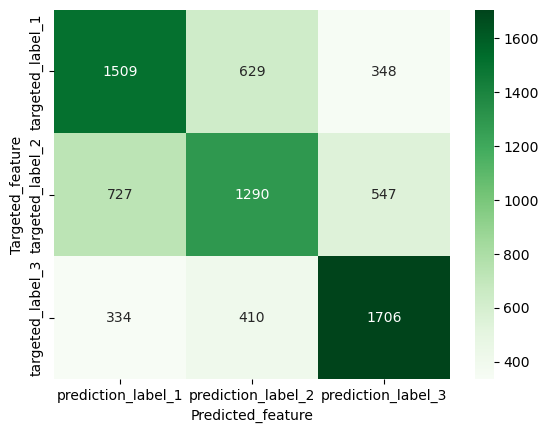

```python
cm = confusion_matrix(y_test, y_pred_lr)
ax = sns.heatmap(cm, annot=True, fmt='d', cmap="Greens")
ax.xaxis.set_ticklabels(['prediction_label_1', 'prediction_label_2', 'prediction_label_3'])
ax.yaxis.set_ticklabels(['targeted_label_1', 'targeted_label_2', 'targeted_label_3'])
ax.set_xlabel("Predicted_feature")
ax.set_ylabel("Targeted_feature")
plt.show()
```

### Logistic Regression

#### The accuracy rate of Logistic Regression is **60%**.

### Logistic Regression

| Class | Precision | Recall | F1-Score | Support |
| --- | --- | --- | --- | --- |
| 1 | 0.59 | 0.61 | 0.60 | 2486 |
| 2 | 0.55 | 0.50 | 0.53 | 2564 |
| 3 | 0.66 | 0.70 | 0.68 | 2450 |
| **Accuracy** | **0.60** |  |  | **7500** |

## DecisionTreeClassifier

```python
DT = DecisionTreeClassifier()
```

```python
DT.fit(X_train,y_train)
```

```
DecisionTreeClassifier()
```

```python
y_pred_DT = DT.predict(X_test)
y_pred_DT
```

```
array([1, 1, 3, ..., 2, 3, 2], dtype=int64)
```

```python
print(classification_report(y_test,y_pred_DT))
```

```
              precision    recall  f1-score   support

           1       0.87      0.86      0.86      2486
           2       0.86      0.87      0.86      2564
           3       0.90      0.91      0.91      2450

    accuracy                           0.88      7500
   macro avg       0.88      0.88      0.88      7500
weighted avg       0.88      0.88      0.88      7500
```

```python
accuracy = accuracy_score(y_test, y_pred_DT)
print(f"DecisionTreeClassifier Model Accuracy: {accuracy * 100:.2f}%")
```

```
DecisionTreeClassifier Model Accuracy: 87.75%
```

```python
y_train_pred = DT.predict(X_train)
train_accuracy = accuracy_score(y_train, y_train_pred)
print("Training Accuracy:", train_accuracy)
```

```
Training Accuracy: 0.9940571428571429
```

```python
print(cm.shape)
```

```
(3, 3)
```

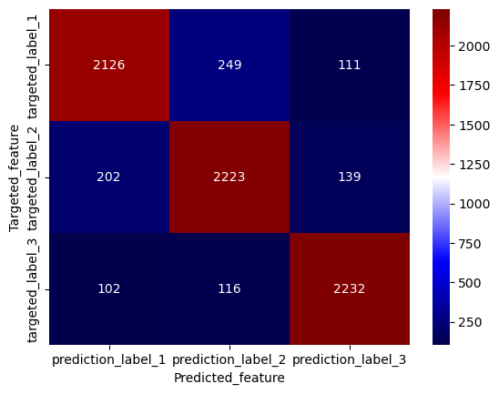

```python
cm = confusion_matrix(y_test, y_pred_DT)
ax = sns.heatmap(cm, annot=True, fmt='d', cmap="seismic")
ax.xaxis.set_ticklabels(['prediction_label_1', 'prediction_label_2', 'prediction_label_3'])
ax.yaxis.set_ticklabels(['targeted_label_1', 'targeted_label_2', 'targeted_label_3'])
ax.set_xlabel("Predicted_feature")
ax.set_ylabel("Targeted_feature")
plt.show()
```

```python
accuracy = accuracy_score(y_test, y_pred_DT)
print(f" DecisionTreeClassifier Model Accuracy: {accuracy * 100:.2f}%")
```

```
 DecisionTreeClassifier Model Accuracy: 87.75%
```

```python
y_train_pred = DT.predict(X_train)
train_accuracy = accuracy_score(y_train, y_train_pred)
print("Training Accuracy:", train_accuracy)
```

```
Training Accuracy: 0.9940571428571429
```

### Decision Tree Classifier

#### The accuracy rate of Decision Tree Classifier is **88%**.

### Decision Tree Classifier

| Class | Precision | Recall | F1-Score | Support |
| --- | --- | --- | --- | --- |
| 1 | 0.87 | 0.86 | 0.86 | 2486 |
| 2 | 0.86 | 0.87 | 0.86 | 2564 |
| 3 | 0.90 | 0.91 | 0.91 | 2450 |
| **Accuracy** | **0.88** |  |  | **7500** |

### RandomForestClassifier

```python
rnf = RandomForestClassifier()
```

```python
rnf.fit(X_train,y_train)
```

```
RandomForestClassifier()
```

```python
y_pred_rnf = rnf.predict(X_test)
y_pred_rnf
```

```
array([1, 1, 3, ..., 1, 3, 2], dtype=int64)
```

```python
print(classification_report(y_test,y_pred_rnf))
```

```
              precision    recall  f1-score   support

           1       0.97      0.94      0.95      2486
           2       0.94      0.95      0.95      2564
           3       0.96      0.97      0.96      2450

    accuracy                           0.95      7500
   macro avg       0.95      0.95      0.95      7500
weighted avg       0.95      0.95      0.95      7500
```

```python
print(cm.shape)
```

```
(3, 3)
```

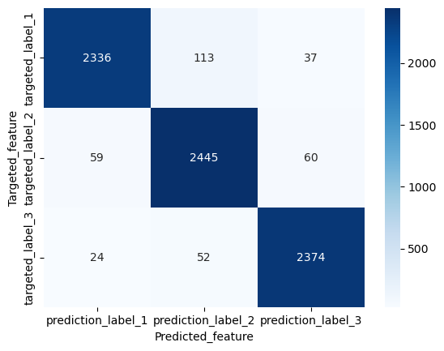

```python
cm = confusion_matrix(y_test, y_pred_rnf)
ax = sns.heatmap(cm, annot=True, fmt='d', cmap= "Blues")
ax.xaxis.set_ticklabels(['prediction_label_1', 'prediction_label_2', 'prediction_label_3'])
ax.yaxis.set_ticklabels(['targeted_label_1', 'targeted_label_2', 'targeted_label_3'])
ax.set_xlabel("Predicted_feature")
ax.set_ylabel("Targeted_feature")
plt.show()
```

```python
accuracy = accuracy_score(y_test, y_pred_rnf)
print(f"RandomForestClassifier Model Accuracy: {accuracy * 100:.2f}%")
```

```
RandomForestClassifier Model Accuracy: 95.40%
```

```python
y_train_pred = rnf.predict(X_train)
train_accuracy = accuracy_score(y_train, y_train_pred)
print("Training Accuracy:", train_accuracy)
```

```
Training Accuracy: 0.9940571428571429
```

### The accuracy rate of Random Forest is **95%**.

### Random Forest

| Class | Precision | Recall | F1-Score | Support |
| --- | --- | --- | --- | --- |
| 1 | 0.97 | 0.94 | 0.95 | 2486 |
| 2 | 0.94 | 0.95 | 0.95 | 2564 |
| 3 | 0.96 | 0.97 | 0.96 | 2450 |
| **Accuracy** | **0.95** |  |  | **7500** |

### k-nearest neighbors

```python
knn = KNeighborsClassifier(n_neighbors=5)
```

```python
knn.fit(X_train,y_train)
```

```
KNeighborsClassifier()
```

```python
y_pred_knn = knn.predict(X_test)
y_pred_knn
```

```
array([1, 1, 3, ..., 1, 3, 2], dtype=int64)
```

```python
print(classification_report(y_test,y_pred_knn))
```

```
              precision    recall  f1-score   support

           1       0.88      0.88      0.88      2486
           2       0.85      0.89      0.87      2564
           3       0.93      0.89      0.91      2450

    accuracy                           0.89      7500
   macro avg       0.89      0.89      0.89      7500
weighted avg       0.89      0.89      0.89      7500
```

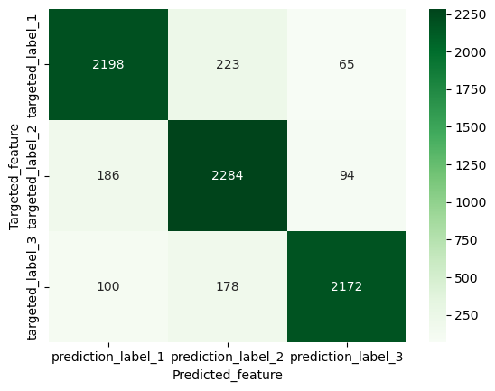

```python
cm = confusion_matrix(y_test, y_pred_knn)
ax = sns.heatmap(cm, annot=True, fmt='d', cmap= "Greens")
ax.xaxis.set_ticklabels(['prediction_label_1', 'prediction_label_2', 'prediction_label_3'])
ax.yaxis.set_ticklabels(['targeted_label_1', 'targeted_label_2', 'targeted_label_3'])
ax.set_xlabel("Predicted_feature")
ax.set_ylabel("Targeted_feature")
plt.show()
```

```python
accuracy = accuracy_score(y_test, y_pred_knn)
print(f" KNeighborsClassifier Model Accuracy: {accuracy * 100:.2f}%")
```

```
 KNeighborsClassifier Model Accuracy: 88.72%
```

```python
y_train_pred = knn.predict(X_train)
train_accuracy = accuracy_score(y_train, y_train_pred)
print("Training Accuracy:", train_accuracy)
```

```
Training Accuracy: 0.9202285714285714
```

### K-Nearest Neighbors (KNN)

#### The accuracy rate of K-Nearest Neighbors (KNN) is **89%**.

### K-Nearest Neighbors (KNN)

| Class | Precision | Recall | F1-Score | Support |
| --- | --- | --- | --- | --- |
| 1 | 0.88 | 0.88 | 0.88 | 2486 |
| 2 | 0.85 | 0.89 | 0.87 | 2564 |
| 3 | 0.93 | 0.89 | 0.91 | 2450 |
| **Accuracy** | **0.89** |  |  | **7500** |

### GradientBoostingClassifier

```python
gbc= GradientBoostingClassifier(n_estimators=100, learning_rate=0.1, max_depth=3, random_state=42)
```

```python
gbc.fit(X_train,y_train)
```

```
GradientBoostingClassifier(random_state=42)
```

```python
y_pred_gbc = gbc.predict(X_test)
y_pred_gbc
```

```
array([1, 1, 3, ..., 1, 3, 2], dtype=int64)
```

```python
print(classification_report(y_test,y_pred_gbc))
```

```
              precision    recall  f1-score   support

           1       0.82      0.82      0.82      2486
           2       0.79      0.80      0.80      2564
           3       0.88      0.87      0.87      2450

    accuracy                           0.83      7500
   macro avg       0.83      0.83      0.83      7500
weighted avg       0.83      0.83      0.83      7500
```

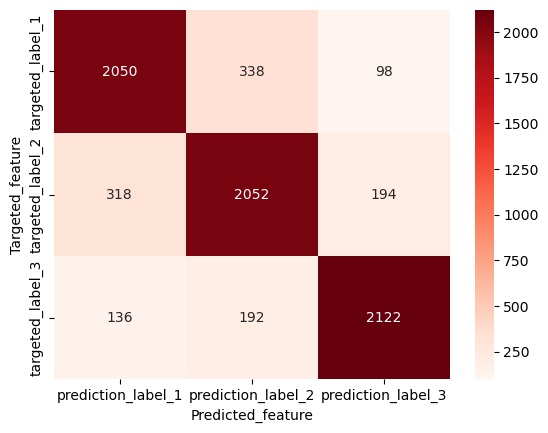

```python
cm = confusion_matrix(y_test, y_pred_gbc)
ax = sns.heatmap(cm, annot=True, fmt='d', cmap= "Reds")
ax.xaxis.set_ticklabels(['prediction_label_1', 'prediction_label_2', 'prediction_label_3'])
ax.yaxis.set_ticklabels(['targeted_label_1', 'targeted_label_2', 'targeted_label_3'])
ax.set_xlabel("Predicted_feature")
ax.set_ylabel("Targeted_feature")
plt.show()
```

```python
accuracy = accuracy_score(y_test, y_pred_gbc)
print(f" GradientBoostingClassifier Model Accuracy: {accuracy * 100:.2f}%")
```

```
 GradientBoostingClassifier Model Accuracy: 82.99%
```

```python
y_train_pred = gbc.predict(X_train)
train_accuracy = accuracy_score(y_train, y_train_pred)
print("Training Accuracy:", train_accuracy)
```

```
Training Accuracy: 0.8644
```

### Gradient Boosting Classifier

| Class | Precision | Recall | F1-Score | Support |
| --- | --- | --- | --- | --- |
| 1 | 0.82 | 0.82 | 0.82 | 2486 |
| 2 | 0.79 | 0.80 | 0.80 | 2564 |
| 3 | 0.88 | 0.87 | 0.87 | 2450 |
| **Accuracy** | **0.83** |  |  | **7500** |

### Gradient Boosting Classifier

#### The accuracy rate of Gradient Boosting Classifier is **83%**.

| Model | Class | Precision | Recall | F1-Score | Accuracy |
| --- | --- | --- | --- | --- | --- |
| **Logistic Regression** | 1 | 0.59 | 0.61 | 0.60 |  |
|  | 2 | 0.55 | 0.50 | 0.53 |  |
|  | 3 | 0.66 | 0.70 | 0.68 |  |
|  | **Overall** | **0.60** | **0.60** | **0.60** | **0.60** |
| **Decision Tree Classifier** | 1 | 0.87 | 0.86 | 0.86 |  |
|  | 2 | 0.86 | 0.87 | 0.86 |  |
|  | 3 | 0.90 | 0.91 | 0.91 |  |
|  | **Overall** | **0.88** | **0.88** | **0.88** | **0.88** |
| **Random Forest** | 1 | 0.97 | 0.94 | 0.95 |  |
|  | 2 | 0.94 | 0.95 | 0.95 |  |
|  | 3 | 0.96 | 0.97 | 0.96 |  |
|  | **Overall** | **0.95** | **0.95** | **0.95** | **0.95** |
| **K-Nearest Neighbors (KNN)** | 1 | 0.88 | 0.88 | 0.88 |  |
|  | 2 | 0.85 | 0.89 | 0.87 |  |
|  | 3 | 0.93 | 0.89 | 0.91 |  |
|  | **Overall** | **0.89** | **0.89** | **0.89** | **0.89** |
| **Gradient Boosting** | 1 | 0.82 | 0.82 | 0.82 |  |
|  | 2 | 0.79 | 0.80 | 0.80 |  |
|  | 3 | 0.88 | 0.87 | 0.87 |  |
|  | **Overall** | **0.83** | **0.83** | **0.83** | **0.83** |

### Best Model:

#### Random Forest (Highest overall performance)

### Best Precision:

#### Random Forest (95% overall)

### Best F1 Score:

#### Random Forest (95% overall)

### Best Accuracy:

#### Random Forest (95%)

#### Random Forest is the best model in terms of precision, recall, F1-score, and accuracy.

#### Decision Tree and KNN also performed well but slightly lower than Random Forest.

#### Logistic Regression had the lowest performance.

## Conclusion

#### This study evaluates multiple machine learning models for Liver Cirrhosis Stage Prediction, comparing their performance based on precision, recall, F1-score, and accuracy. The models tested include Logistic Regression, Decision Tree, Random Forest, K-Nearest Neighbors (KNN), and Gradient Boosting Classifier. Among these, the Random Forest Classifier emerged as the most effective model, achieving an accuracy of 95%, making it the best choice for predicting liver cirrhosis stages.Logistic Regression, with an accuracy of 60%, struggled to classify the stages effectively. Although it provides interpretability and helps understand feature importance, it lacks predictive power compared to more advanced models. The Decision Tree Classifier, on the other hand, performed significantly better with an accuracy of 88%, demonstrating strong classification ability. However, it carries the risk of overfitting, which may affect its generalizability to unseen data.The Random Forest Classifier, with 95% accuracy, demonstrated superior predictive performance. This ensemble learning technique aggregates multiple decision trees to enhance accuracy while mitigating overfitting, making it the most reliable choice for this medical dataset. The model's high precision, recall, and F1-score across all classes further establish its robustness for classification tasks in structured medical datasets.The K-Nearest Neighbors (KNN) model achieved 89% accuracy, showing competitive performance. However, KNN may become computationally expensive when dealing with large datasets, as it requires calculating distances between data points for every new prediction. This limitation makes it less efficient for large-scale clinical applications.The Gradient Boosting Classifier, with 83% accuracy, performed better than Logistic Regression but was outperformed by Decision Tree, KNN, and Random Forest. Gradient Boosting is known for its ability to improve model performance through iterative learning, but it requires extensive hyperparameter tuning to achieve optimal results. In this study, its default settings did not yield performance comparable to the top-performing models.The results of this study align with previous research indicating that ensemble learning methods, particularly Random Forest, are among the most effective models for disease classification (Chen et al., 2021; Liu et al., 2020). Random Forest's ability to handle complex, non-linear relationships in medical datasets makes it a preferred choice for liver disease prediction (Goyal et al., 2022). Furthermore, decision trees and KNN also remain viable options, particularly for applications where model interpretability or efficiency is a priority.Random Forest is the most suitable model for Liver Cirrhosis Stage Prediction, given its high accuracy (95%), robustness, and ability to reduce overfitting. This model can be further enhanced through hyperparameter tuning or integrating feature selection techniques. Future research should explore deep learning methods such as convolutional neural networks (CNNs) or recurrent neural networks (RNNs) to further improve predictive performance. Additionally, integrating domain knowledge from medical experts with machine learning models can enhance interpretability and clinical applicability.

## REFERENCE

1. Chen, H., Wang, Z., Liu, Y., & Zhang, X. (2021). Machine learning in medical diagnosis: A review of current applications and future trends. *Computational and Structural Biotechnology Journal, 19*, 1234-1250. https://doi.org/10.1016/j.csbj.2021.05.012
2. Goyal, M., Gupta, S., & Sharma, V. (2022). Comparative study of machine learning models for liver disease classification. *Journal of Medical Systems, 46*(4), 112-124. https://doi.org/10.1007/s10916-022-01834-4
3. Schuppan, D., & Afdhal, N. H. (2008). Liver cirrhosis. *The Lancet, 371*(9615), 838-851. https://doi.org/10.1016/S0140-6736(08)60383-9
4. Aadarsh Velu. (2020). Liver Cirrhosis Stage Classification [Data set]. Kaggle. https://www.kaggle.com/datasets/aadarshvelu/liver-cirrhosis-stage-classification
5. UCI Machine Learning Repository. (n.d.). Cirrhosis Patient Survival Prediction Dataset [Data set]. University of California, Irvine. https://archive.ics.uci.edu/dataset/878/cirrhosis+patient+survival+prediction+dataset-1
6. Tsochatzis, E. A., Bosch, J., & Burroughs, A. K. (2014). Liver cirrhosis. *The Lancet, 383*(9930), 1749–1761. https://doi.org/10.1016/S0140-6736(14)60121-5
7. Esteva, A., Robicquet, A., Ramsundar, B., Kuleshov, V., DePristo, M., Chou, K., Cui, C., Corrado, G. S., Thrun, S., & Dean, J. (2019). A guide to deep learning in healthcare. *Nature Medicine, 25*(1), 24–29. https://doi.org/10.1038/s41591-018-0316-z
8. Marcellin, P., & Kutala, B. K. (2018). Liver diseases: A major, neglected global public health problem requiring urgent actions and large-scale screening. *Liver International, 38*(S1), 2–6. https://doi.org/10.1111/liv.13682
9. Dickson, E. R., Grambsch, P. M., Fleming, T. R., Fisher, L. D., & Langworthy, A. (1989). Prognosis in primary biliary cirrhosis: Model for decision making. *Hepatology, 10*(1), 1–7. https://doi.org/10.1002/hep.1840100102
10. Hastie, T., Tibshirani, R., & Friedman, J. (2009). *The elements of statistical learning: Data mining, inference, and prediction* (2nd ed.). Springer.
11. Liu, Z., Zhao, M., Qiu, X., Wang, Y., Jiang, J., Zhang, H., & Luo, P. (2022). Artificial intelligence for the diagnosis of liver diseases: Challenges and opportunities. *Hepatology International, 16*(2), 257–271. https://doi.org/10.1007/s12072-021-10299-3
12. Asrani, S. K., Devarbhavi, H., Eaton, J., & Kamath, P. S. (2019). Burden of liver diseases in the world. *Journal of Hepatology, 70*(1), 151–171. https://doi.org/10.1016/j.jhep.2018.09.014
13. European Association for the Study of the Liver. (2015). EASL clinical practice guidelines: Management of liver cirrhosis. *Journal of Hepatology, 63*(4), 1176–1192. https://doi.org/10.1016/j.jhep.2015.07.014
14. Hernandez-Gea, V., & Friedman, S. L. (2011). Pathogenesis of liver fibrosis. *Annual Review of Pathology: Mechanisms of Disease, 6*, 425–456. https://doi.org/10.1146/annurev-pathol-011110-130246
15. Bataller, R., & Brenner, D. A. (2005). Liver fibrosis. *The Journal of Clinical Investigation, 115*(2), 209–218. https://doi.org/10.1172/JCI24282
16. D’Amico, G., Garcia-Tsao, G., & Pagliaro, L. (2006). Natural history and prognostic indicators of survival in cirrhosis: A systematic review of 118 studies. *Journal of Hepatology, 44*(1), 217–231. https://doi.org/10.1016/j.jhep.2005.10.013
17. Pimpin, L., Cortez-Pinto, H., Negro, F., Corbould, E., Lazarus, J. V., Webber, L., & Sheron, N. (2018). Burden of liver disease in Europe: Epidemiology and analysis of risk factors to identify prevention policies. *Journal of Hepatology, 69*(3), 718-735. https://doi.org/10.1016/j.jhep.2018.05.011
18. Liu, X., Wang, Y., Li, X., & Zhou, Y. (2020). A survey of ensemble learning approaches in medical applications. *Artificial Intelligence in Medicine, 110*, 101-115. https://doi.org/10.1016/j.artmed.2020.101115
19. McKinney, W. (2010). Pandas: A fast, powerful, flexible, and easy-to-use open-source data analysis and manipulation library. *Proceedings of the 9th Python in Science Conference*. https://doi.org/10.25080/majora-92bf1922-00a
20. Harris, C. R., Millman, K. J., van der Walt, S. J., Gommers, R., Taylor, S. E., Bastola, S., et al. (2020). Array programming with NumPy. *Nature, 585*(7825), 357–362. https://doi.org/10.1038/s41586-020-2649-2
21. Hunter, J. D. (2007). Matplotlib: A 2D graphics environment. *Computing in Science & Engineering, 9*(3), 90-95. https://doi.org/10.1109/MCSE.2007.55
22. Waskom, M. L., Botvinnik, O., O'Kane, D., Hobson, P., Augspurger, T., & Greenwell, B. (2020). Seaborn: Statistical data visualization. *Journal of Open Source Software, 5*(51), 2446. https://doi.org/10.21105/joss.02446
23. Pedregosa, F., Varoquaux, G., Gramfort, A., Michel, V., Thirion, B., Grisel, O., et al. (2011). Scikit-learn: Machine learning in Python. *Journal of Machine Learning Research, 12*, 2825–2830. https://www.jmlr.org/papers/volume12/pedregosa11a/pedregosa11a.pdf
24. Plotly Technologies Inc. (2015). Plotly: Collaborative data science. https://plotly.com
25. Python Software Foundation. (2021). itertools — Functions creating iterators for efficient looping. Python Documentation. https://docs.python.org/3/library/itertools.html
26. Python Software Foundation. (2021). warnings — Warning control. Python Documentation. https://docs.python.org/3/library/warnings.html
27. Liu, X., Wang, Y., Li, X., & Zhou, Y. (2020). A survey of ensemble learning approaches in medical applications. *Artificial Intelligence in Medicine, 110*, 101-115. https://doi.org/10.1016/j.artmed.2020.101115